# W3cubDocs

Including upper and lower limits in error bars

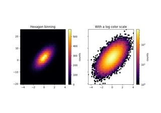

[Hexagonal binned plot](https://matplotlib.org/stable/gallery/statistics/hexbin_demo.html#sphx-glr-gallery-statistics-hexbin-demo-py)

Hexagonal binned plot

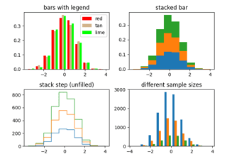

[The histogram (hist) function with multiple data sets](https://matplotlib.org/stable/gallery/statistics/histogram_multihist.html#sphx-glr-gallery-statistics-histogram-multihist-py)

The histogram (hist) function with multiple data sets

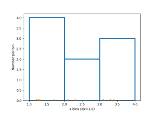

[Histogram bins, density, and weight](https://matplotlib.org/stable/gallery/statistics/histogram_normalization.html#sphx-glr-gallery-statistics-histogram-normalization-py)

Histogram bins, density, and weight

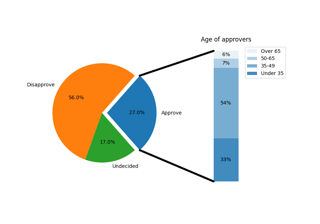

[Bar of pie](https://matplotlib.org/stable/gallery/pie_and_polar_charts/bar_of_pie.html#sphx-glr-gallery-pie-and-polar-charts-bar-of-pie-py)

Bar of pie

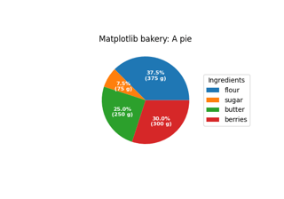

[Labeling a pie and a donut](https://matplotlib.org/stable/gallery/pie_and_polar_charts/pie_and_donut_labels.html#sphx-glr-gallery-pie-and-polar-charts-pie-and-donut-labels-py)

Labeling a pie and a donut

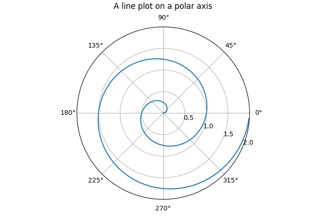

[Polar plot](https://matplotlib.org/stable/gallery/pie_and_polar_charts/polar_demo.html#sphx-glr-gallery-pie-and-polar-charts-polar-demo-py)

Polar plot

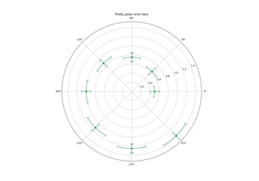

[Error bar rendering on polar axis](https://matplotlib.org/stable/gallery/pie_and_polar_charts/polar_error_caps.html#sphx-glr-gallery-pie-and-polar-charts-polar-error-caps-py)

Error bar rendering on polar axis

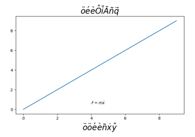

[Accented text](https://matplotlib.org/stable/gallery/text_labels_and_annotations/accented_text.html#sphx-glr-gallery-text-labels-and-annotations-accented-text-py)

Accented text

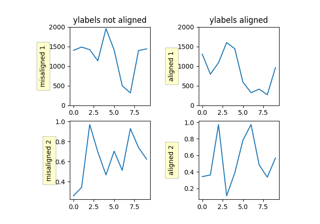

[Align y-labels](https://matplotlib.org/stable/gallery/text_labels_and_annotations/align_ylabels.html#sphx-glr-gallery-text-labels-and-annotations-align-ylabels-py)

Align y-labels

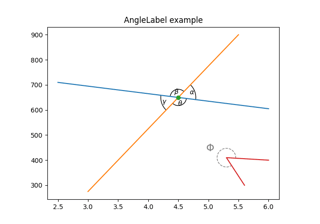

[Scale invariant angle label](https://matplotlib.org/stable/gallery/text_labels_and_annotations/angle_annotation.html#sphx-glr-gallery-text-labels-and-annotations-angle-annotation-py)

Scale invariant angle label

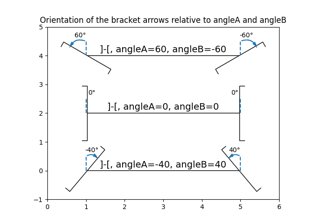

[Angle annotations on bracket arrows](https://matplotlib.org/stable/gallery/text_labels_and_annotations/angles_on_bracket_arrows.html#sphx-glr-gallery-text-labels-and-annotations-angles-on-bracket-arrows-py)

Angle annotations on bracket arrows

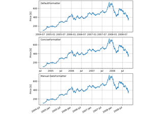

[Date tick labels](https://matplotlib.org/stable/gallery/text_labels_and_annotations/date.html#sphx-glr-gallery-text-labels-and-annotations-date-py)

Date tick labels

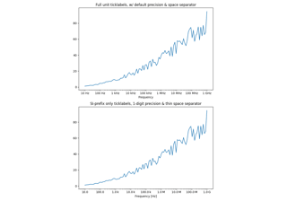

[Labeling ticks using engineering notation](https://matplotlib.org/stable/gallery/text_labels_and_annotations/engineering_formatter.html#sphx-glr-gallery-text-labels-and-annotations-engineering-formatter-py)

Labeling ticks using engineering notation

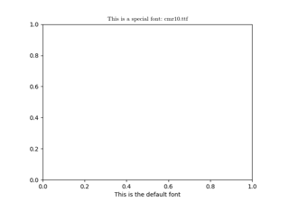

[Using ttf font files](https://matplotlib.org/stable/gallery/text_labels_and_annotations/font_file.html#sphx-glr-gallery-text-labels-and-annotations-font-file-py)

Using ttf font files

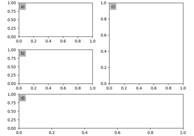

[Labelling subplots](https://matplotlib.org/stable/gallery/text_labels_and_annotations/label_subplots.html#sphx-glr-gallery-text-labels-and-annotations-label-subplots-py)

Labelling subplots

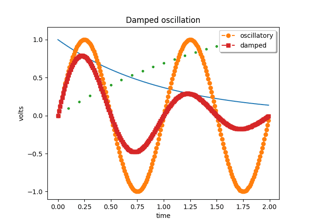

[Legend Demo](https://matplotlib.org/stable/gallery/text_labels_and_annotations/legend_demo.html#sphx-glr-gallery-text-labels-and-annotations-legend-demo-py)

Legend Demo

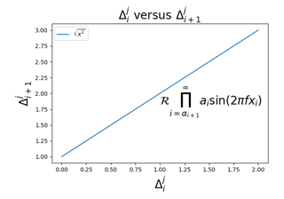

[Mathtext](https://matplotlib.org/stable/gallery/text_labels_and_annotations/mathtext_demo.html#sphx-glr-gallery-text-labels-and-annotations-mathtext-demo-py)

Mathtext

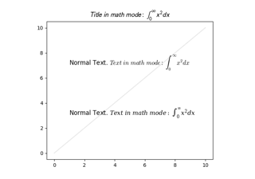

[Math fontfamily](https://matplotlib.org/stable/gallery/text_labels_and_annotations/mathtext_fontfamily_example.html#sphx-glr-gallery-text-labels-and-annotations-mathtext-fontfamily-example-py)

Math fontfamily

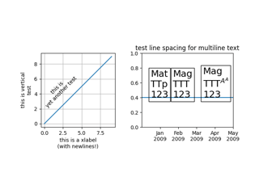

[Multiline](https://matplotlib.org/stable/gallery/text_labels_and_annotations/multiline.html#sphx-glr-gallery-text-labels-and-annotations-multiline-py)

Multiline

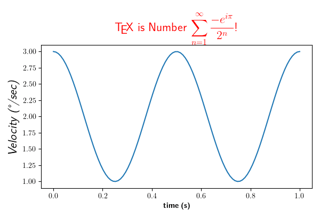

[Rendering math equations using TeX](https://matplotlib.org/stable/gallery/text_labels_and_annotations/tex_demo.html#sphx-glr-gallery-text-labels-and-annotations-tex-demo-py)

Rendering math equations using TeX

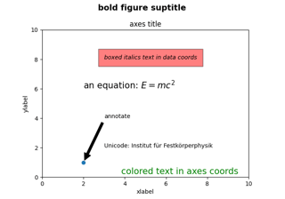

[Text Commands](https://matplotlib.org/stable/gallery/text_labels_and_annotations/text_commands.html#sphx-glr-gallery-text-labels-and-annotations-text-commands-py)

Text Commands

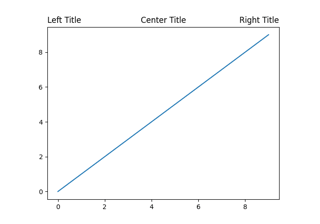

[Title positioning](https://matplotlib.org/stable/gallery/text_labels_and_annotations/titles_demo.html#sphx-glr-gallery-text-labels-and-annotations-titles-demo-py)

Title positioning

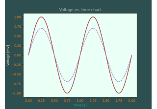

[Color Demo](https://matplotlib.org/stable/gallery/color/color_demo.html#sphx-glr-gallery-color-color-demo-py)

Color Demo

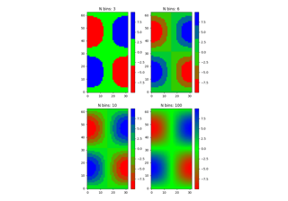

[Creating a colormap from a list of colors](https://matplotlib.org/stable/gallery/color/custom_cmap.html#sphx-glr-gallery-color-custom-cmap-py)